# Multi-Agent Systems Homework 6

Thomas Maaiveld (t.m.maaiveld@student.vu.nl); 2528586

# 1 $\enspace$ Multi-Armed Bandits

## 1.1 Thompson Sampling for single bandit

The following plots show the probability density of $B(x;\alpha,\beta)$ for the different combinations of $\alpha$ and $\beta$ shown in the legend. Noticeable patterns are that higher values for $\alpha$ result in a right-leaning distributions, while higher values for $\beta$ produce a left-leaning distribution. Combinations can be mixed to produce different distributions, while setting either parameter to 1 while the other is greater than 1 leads to a sloped probability distribution function in either direction.

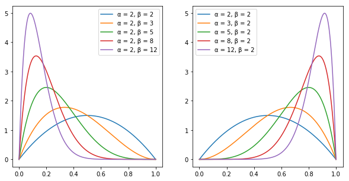

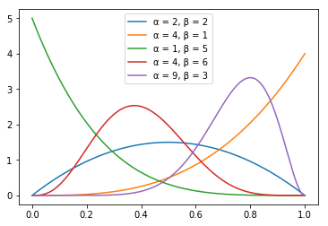

The Thompson update rule was implemented and tested with a bandit with a true probability $p=0.3$ of sampling reward $1$. The following two plots show the evolution of the mean over generations, both for the expected value and theoretical variance derived from the beta distribution for updated parameters $\alpha$ and $\beta$, as well as for the values sampled from the bandit in the code above. The expected value for the mean derived for parameters $\alpha$ and $\beta$ closely follows the calculated sample mean for generations of the algorithm (each generation being a sampled reward from the bandit) and approaches it in the limit. The same holds for the variance.

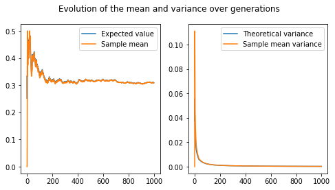

The plot and animation below show the evolution of the modeled probability density function of $p$ over generations, distributed according to the beta distribution for computed $\alpha$ and $\beta$ and its convergence towards $p = 0.3$ as samples are drawn from the bandit. The peak of the distribution approaches the true probability of the bandit.

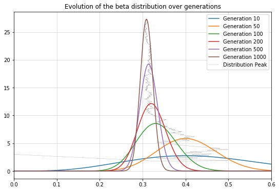

[video not shown]

$\textbf{Multiple bandits}$

The experiment setup was implemented using two bandits with true probabilities $p=0.45$ and $p=0.55$. 1000 iterations of the algorithm were used to find the modeled probability distributions of the bandits.

The distribution of the inferior bandit ($p = 0.45$) is updated less frequently and takes longer to approach the proper distribution. This is presumably because the $\text{argmax}(u_k)$ will rarely choose $u_k$ for an inferior bandit $k$ if a better sampled $u_k$ is available, meaning its parameters $\alpha_k$ and $\beta_k$ are updated less often.The animation below shows the development of the distribution of $p$ for both bandits. The vertical lines show the actual values for $p_k$ for each of the $k$ bandits.

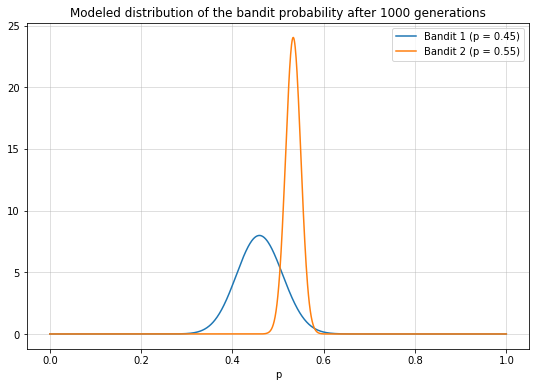

[video not shown]

$\textbf{Comparison with $\epsilon$-greedy and UCB}$

A setup with two bandits with true probabilities $p=0.3$ and $p=0.7$ was used to show the difference between the three approaches. 20 runs of 2000 episodes were conducted to generate the results. The plots for the average cumulative reward and regret over time for the Thompson sampling, $\epsilon$-greedy and UCB agents are given below, for parameter settings $\epsilon = 0.1$ and $c = 2$. In terms of reward, Thompson performs best, followed by $\epsilon$-greedy and UCB.

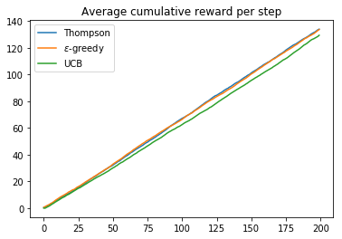

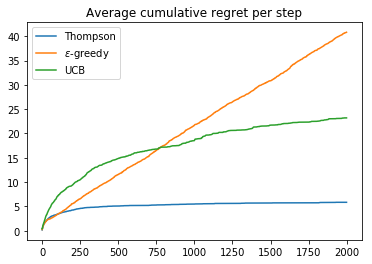

# 2 $\enspace$ Reinforcement Learning: Cliff Walking

[figure not shown]

$\textbf{Different policies for Q-learning and SARSA}$

$\epsilon$ was set to $0.1$ for both approaches, and gridworld experiments were conducted. The optimal policies, accumulated average reward per time step and episode time per time step shown below were obtained by using the mode over all policies (a 'majority vote') and averaging over twenty episodes respectively. Each run consisted of 10000 iterations of the game, of which the first 200 are shown in the plot and the rest are used to find the optimal policy. Some areas remain unexplored even after 10000 iterations, since the probability of visiting these is so low.

The optimal policies show the expected difference between Q-learning and SARSA. While Q-learning quickly converges to the optimal policy along the cliff, SARSA learns the safer path one step away from the edge. While Q-learning uses $\epsilon$-greedy action selection to determine which states will be visited in order to be updated, it only maximizes the action value over the actions from that next state to estimate its action value. SARSA, on the other hand, takes this exploration into account. Thus, state action pairs that lead to a cliff state show a high reward by maximizing the subsequent action for Q-learning. If it falls off, the negative reward only directly affects the state action pair for the current state, not for the preceding state action pair that led it to the square next to the cliff. If SARSA ends up falling off, the value of the state action pair leading to the cliffside will also receive a penalty, meaning these will rarely be selected. This minimizes the chance of falling off the edge by staying at least two squares away from it, meaning two subsequent exploration rolls would be necessary in order for it to fall. On the other hand, this results in a slower performance, but since the penalty for falling is steep ($+100$), this strategy results in higher average reward.

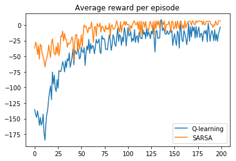

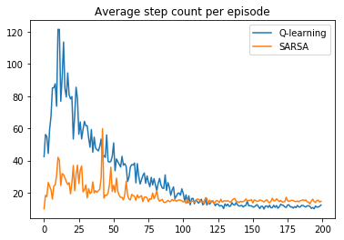

```
Aggregated optimal policy (Q-learning)
[['↑' '↑' '↑' '↑' '↓' '→' '↓' '↓' '↑' '↓']
 ['↓' '↑' '↓' '↓' '↓' '→' '↓' '↓' '↓' '↓']
 ['→' '↓' '↓' '↓' '↓' '↓' '↓' '↓' '→' '↓']
 ['↓' '→' '→' '↓' '→' '↓' '→' '→' '→' '↓']
 ['→' '→' '→' '→' '→' '→' '→' '→' '→' '↓']
 ['↑' '×' '×' '×' '×' '×' '×' '×' '×' '⚑']]

Aggregated optimal policy (SARSA)
[['↑' '↓' '↓' '↓' '↓' '↓' '↓' '↓' '↓' '↓']
 ['↓' '↓' '↓' '↓' '↓' '↓' '↓' '↓' '↓' '↓']
 ['→' '→' '↓' '↓' '↓' '↓' '↓' '↓' '→' '↓']
 ['→' '→' '→' '→' '→' '→' '→' '→' '→' '↓']
 ['↑' '↑' '↑' '↑' '↑' '↑' '↑' '↑' '→' '↓']
 ['↑' '×' '×' '×' '×' '×' '×' '×' '×' '⚑']]
```

$\textbf{Influence of $\epsilon$}$

The code below shows a comparison for different parameter settings ($\epsilon=0.1$, $\epsilon=0.3$ and $\epsilon=0.5$). The results are averaged over 30 runs, and optimal policies were chosen by majority vote for each state over runs. Increasing $\epsilon$ has a significant effect on the reward and episode length as generations increase. Both algorithms take more episodes to maximize their score and are also able to achieve significantly less total reward after many episodes as they tumble off the cliff more often when choosing exploring actions.

Clearly, introducing increasing amounts of stochasticity to this environment show an advantage SARSA has over Q-learning. Its accumulated reward also decreases as it is forced to take a longer path, but this is notably less than the detriment to Q-learning's performance.

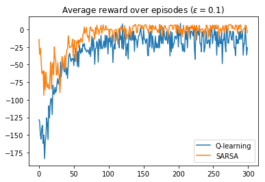

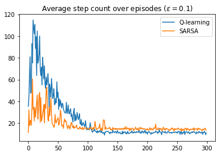

```
Aggregated optimal policy (Q-learning)
[['↑' '↑' '←' '↑' '↑' '↑' '↓' '↑' '→' '↑']
 ['↑' '→' '↑' '↑' '↑' '↓' '↓' '↓' '↓' '↓']
 ['↓' '↓' '↓' '↓' '↓' '↓' '↓' '↓' '↓' '↓']
 ['↓' '→' '↓' '↓' '↓' '→' '↓' '↓' '→' '↓']
 ['→' '→' '→' '→' '→' '→' '→' '→' '→' '↓']
 ['↑' '×' '×' '×' '×' '×' '×' '×' '×' '⚑']]

Aggregated optimal policy (SARSA)
[['→' '→' '↓' '↓' '→' '→' '↓' '↓' '↓' '↓']
 ['↓' '↓' '↓' '↓' '↓' '↓' '↓' '↓' '↓' '↓']
 ['↓' '↓' '↓' '↓' '↓' '↓' '↓' '↓' '↓' '↓']
 ['→' '→' '→' '→' '→' '→' '→' '→' '→' '↓']
 ['↑' '↑' '↑' '↑' '↑' '↑' '↑' '↑' '→' '↓']
 ['↑' '×' '×' '×' '×' '×' '×' '×' '×' '⚑']]
```

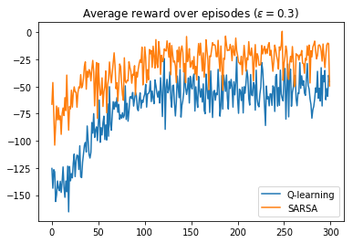

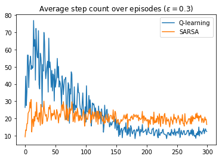

```
Aggregated optimal policy (Q-learning)
[['←' '↑' '↑' '↓' '→' '↓' '→' '↓' '↑' '↓']
 ['↓' '↓' '↓' '↓' '↓' '↓' '↓' '↓' '↓' '↓']
 ['↓' '↓' '↓' '↓' '↓' '↓' '↓' '↓' '↓' '↓']
 ['↓' '↓' '→' '→' '→' '→' '→' '↓' '→' '↓']
 ['→' '→' '→' '→' '→' '→' '→' '→' '→' '↓']
 ['↑' '×' '×' '×' '×' '×' '×' '×' '×' '⚑']]

Aggregated optimal policy (SARSA)
[['→' '→' '↓' '↓' '↓' '↓' '↓' '↓' '↓' '↓']
 ['→' '→' '→' '↓' '↓' '↓' '↓' '↓' '↓' '↓']
 ['→' '→' '→' '→' '→' '→' '→' '→' '↓' '↓']
 ['↑' '↑' '→' '↑' '→' '→' '→' '→' '→' '↓']
 ['↑' '↑' '↑' '↑' '↑' '↑' '↑' '↑' '→' '↓']
 ['↑' '×' '×' '×' '×' '×' '×' '×' '×' '⚑']]
```

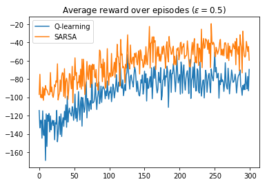

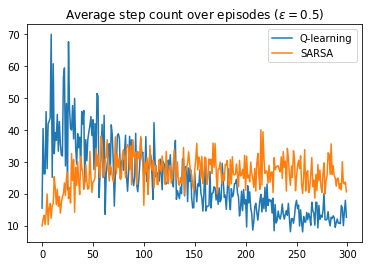

```
Aggregated optimal policy (Q-learning)
[['↓' '↓' '↓' '↓' '↓' '↓' '↓' '↓' '↓' '↓']
 ['→' '↓' '↓' '↓' '↓' '↓' '↓' '↓' '↓' '↓']
 ['↓' '↓' '↓' '↓' '↓' '↓' '↓' '↓' '↓' '↓']
 ['↓' '↓' '↓' '→' '→' '→' '→' '↓' '↓' '↓']
 ['→' '→' '→' '→' '→' '→' '→' '→' '→' '↓']
 ['↑' '×' '×' '×' '×' '×' '×' '×' '×' '⚑']]

Aggregated optimal policy (SARSA)
[['→' '→' '→' '→' '→' '→' '→' '↓' '↓' '↓']
 ['→' '→' '→' '→' '→' '→' '→' '→' '→' '↓']
 ['↑' '→' '→' '→' '→' '→' '→' '→' '→' '↓']
 ['↑' '↑' '↑' '→' '↑' '↑' '↑' '→' '→' '↓']
 ['↑' '↑' '↑' '↑' '↑' '↑' '↑' '↑' '→' '↓']
 ['↑' '×' '×' '×' '×' '×' '×' '×' '×' '⚑']]
```